# Self-starting non-linear PI models

George N. White III

4/20/2017

## Introduction

This is an R Markdown document.

R now has “self-starting” non-linear models. Pre-built versions of the most widely used 2-parameter models are available in the base R packages. Platt et al 1977 propose using the initial slope `alpha` and the specific production rate, `PmB` at “optimal” light intensity. For two-parameter models whwere there is no “optimum”, we use `PsB`, the “saturation” rate.

Taken from `selfStart {stats}`

```r
pos.st <- which("package:stats" == search())
mSS <- apropos("^SS..", where = TRUE, ignore.case = FALSE)
(mSS <- unname(mSS[names(mSS) == pos.st]))
```

```
##  [1] "SSasymp"     "SSasympOff"  "SSasympOrig" "SSbiexp"     "SSfol"
##  [6] "SSfpl"       "SSgompertz"  "SSlogis"     "SSmicmen"    "SSweibull"
```

```r
fSS <- sapply(mSS, get, pos = pos.st, mode = "function")
all(sapply(fSS, inherits, "selfStart"))  # -> TRUE
```

```
## [1] TRUE
```

## Show the argument list of each self-starting function:

```r
str(fSS, give.attr = FALSE)
```

```
## List of 10
##  $ SSasymp    :function (input, Asym, R0, lrc)
##  $ SSasympOff :function (input, Asym, lrc, c0)
##  $ SSasympOrig:function (input, Asym, lrc)
##  $ SSbiexp    :function (input, A1, lrc1, A2, lrc2)
##  $ SSfol      :function (Dose, input, lKe, lKa, lCl)
##  $ SSfpl      :function (input, A, B, xmid, scal)
##  $ SSgompertz :function (x, Asym, b2, b3)
##  $ SSlogis    :function (input, Asym, xmid, scal)
##  $ SSmicmen   :function (input, Vm, K)
##  $ SSweibull  :function (x, Asym, Drop, lrc, pwr)
```

## PI models

Consider the following sample data:

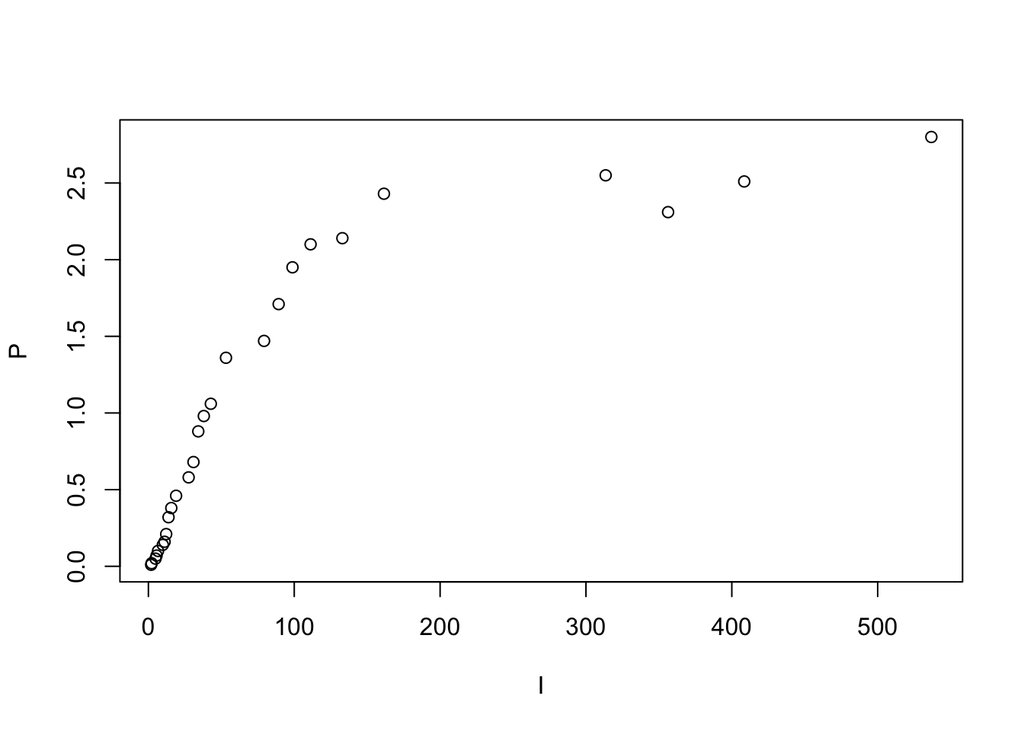

```r
with(PI.df, plot(P~I))
```

Important features of this plot are the saturation value, `PsB` and the slope, `alphaB` ot the origin.

## Michaelis-Menten model

The Michaelis-Menten model `Vm*x/(K+x)` has a shape similar to the above plot and was used by Jasby A.D. and Platt T., 1976. Mathematical formulation of the relationship between photosynthesis and light for phytoplankton. Limnol. Oceanogr. 21:540–547. For PI applications, `Vm = PsB` and `alphaB = PsB/K’

```r
getInitial(P ~ SSmicmen(I, PsB, K), data = PI.df)
```

```
##       PsB         K
##  3.275932 89.152728
```

```r
MM.nls <- nls(P ~ SSmicmen(I, PsB, K), data = PI.df)
MM.nls
```

```
## Nonlinear regression model
##   model: P ~ SSmicmen(I, PsB, K)
##    data: PI.df
##    PsB      K
##  3.276 89.153
##  residual sum-of-squares: 0.69
##
## Number of iterations to convergence: 0
## Achieved convergence tolerance: 1.271e-06
```

```r
summary(MM.nls)
```

```
##
## Formula: P ~ SSmicmen(I, PsB, K)
##
## Parameters:
##     Estimate Std. Error t value Pr(>|t|)
## PsB   3.2759     0.1494  21.933  < 2e-16 ***
## K    89.1527    10.3266   8.633  5.7e-09 ***
## ---
## Signif. codes:  0 '***' 0.001 '**' 0.01 '*' 0.05 '.' 0.1 ' ' 1
##
## Residual standard error: 0.1661 on 25 degrees of freedom
##
## Number of iterations to convergence: 0
## Achieved convergence tolerance: 1.271e-06
```

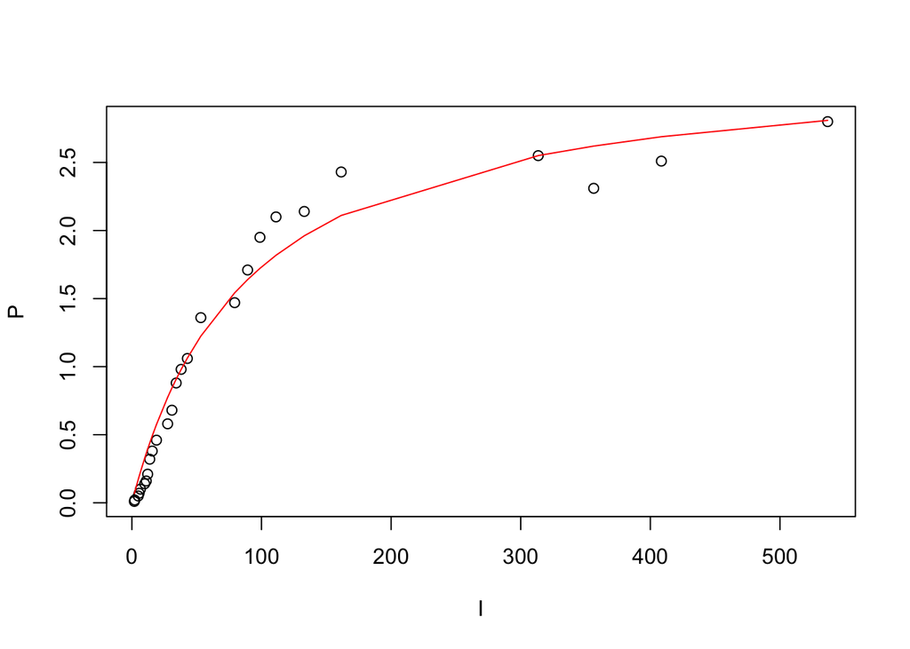

```r
c.MM <- coef(MM.nls)
c.MM["alphaB"] <- c.MM["PsB"]/c.MM["K"]
with(PI.df, plot(P~I))
with(PI.df, lines(I, SSmicmen(I, c.MM["PsB"], c.MM["K"]), col='red')
     )
```

```r
confint(MM.nls)
```

```
##          2.5%      97.5%
## PsB  3.002561   3.582795
## K   71.668325 111.148969
```

## Platt et al 1980 using SSasympOrig

Platt et al 1980 adopted a different model to account for observations in which the P decreases at high I values.

```
   PB = PsB*(1 - exp(-alphaB*I/PsB))*exp(-betaB*I/PsB)
```

When the parameter `betaB` in this model is zero, it reduces to the following standard self-starting model:

`SSasympOrig = function(x, Asym, lrc) = Asym*(1 -exp(-exp(lrc)*x))` where `Asym` is the asymptotic value, , and `lrc` is natural log of the rate constant, `rc`.

For P–I models, `Asym = PsB`, the saturation rate, and `rc = alphaB/PsB`. We can define `SSProduction` using `SSasympOrig` as shown below. Using the parameter estimates from the Micaelis-Menton model, however, produces a poor fit.

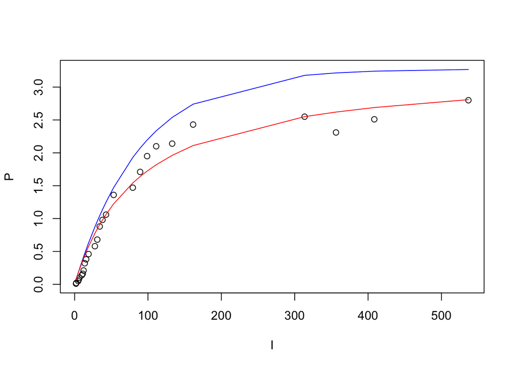

```r
SSProduction <- function(Irradiance, alphaB, PsB)
{ SSasympOrig(Irradiance, PsB, log(alphaB/PsB))}
PsB <- c.MM["PsB"]
alphaB <- c.MM["alphaB"]
with(PI.df, {
               plot(I, P, ylim=c(0, PsB))
               lines(I, SSProduction(I, alphaB, PsB), col='blue')
               lines(I, SSmicmen(I, c.MM["PsB"], c.MM["K"]), col='red')
            })
```

Next, we estimate the parameters using `SSasympOrig`. Note that both `PmB` and `alphaB` are smaller than for the Michaelis-Menton model.

```r
lrc <- log(alphaB/PsB)
(getInitial(P ~ SSasympOrig(I, PsB, lrc), data = PI.df))
```

```
##       PsB       lrc
##  2.635119 -4.441478
```

```r
asymp.nls <- nls(P ~ SSasympOrig(I, PsB, lrc), data = PI.df)
asymp.nls
```

```
## Nonlinear regression model
##   model: P ~ SSasympOrig(I, PsB, lrc)
##    data: PI.df
##    PsB    lrc
##  2.635 -4.441
##  residual sum-of-squares: 0.401
##
## Number of iterations to convergence: 0
## Achieved convergence tolerance: 5.937e-07
```

```r
summary(asymp.nls)
```

```
##
## Formula: P ~ SSasympOrig(I, PsB, lrc)
##
## Parameters:
##     Estimate Std. Error t value Pr(>|t|)
## PsB  2.63512    0.06688   39.40   <2e-16 ***
## lrc -4.44148    0.06208  -71.54   <2e-16 ***
## ---
## Signif. codes:  0 '***' 0.001 '**' 0.01 '*' 0.05 '.' 0.1 ' ' 1
##
## Residual standard error: 0.1266 on 25 degrees of freedom
##
## Number of iterations to convergence: 0
## Achieved convergence tolerance: 5.937e-07
```

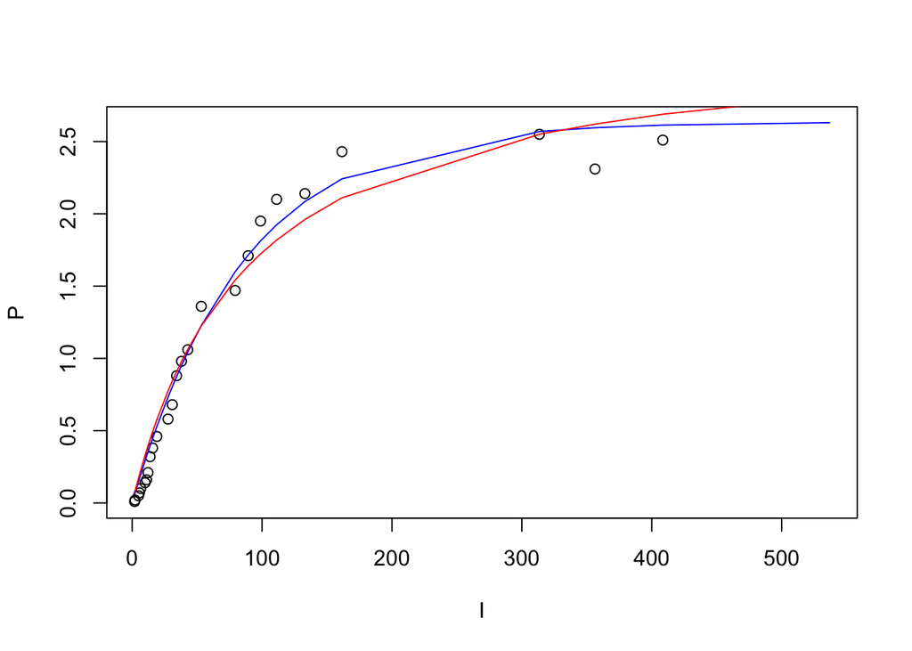

```r
c.asymp <- coef(asymp.nls)
c.asymp["alphaB"] <- exp(c.asymp["lrc"])*c.asymp["PsB"]
PsB <- c.asymp["PsB"]
alphaB <- c.asymp["alphaB"]
with(PI.df, {
               plot(I, P, ylim=c(0, PsB))
               lines(I, SSProduction(I, alphaB, PsB), col='blue')
               lines(I, SSmicmen(I, c.MM["PsB"], c.MM["K"]), col='red')
            })
```

```r
confint(asymp.nls)
```

```
##          2.5%     97.5%
## PsB  2.503132  2.773063
## lrc -4.564629 -4.318489
```

## Weibull

The Weibull function adds a third parameter, `pwr` to the asymptotic model, giving:

```
    y = Asym-Drop*exp(-exp(lrc)*x^pwr
```

The zero-intercept constraint requires`Drop=Asym`.

```r
lrc <- log(alphaB/PsB)
pwr <- 1
Drop = PsB
(getInitial(P ~ SSweibull(I, PsB, Drop, lrc, pwr), data = PI.df))
```

```
##       PsB      Drop       lrc       pwr
##  2.558808  2.617449 -4.941978  1.146789
```

```r
weibull.nls <- nls(P ~ SSweibull(I, PsB, Drop, lrc, pwr), data = PI.df)
weibull.nls
```

```
## Nonlinear regression model
##   model: P ~ SSweibull(I, PsB, Drop, lrc, pwr)
##    data: PI.df
##    PsB   Drop    lrc    pwr
##  2.559  2.617 -4.942  1.147
##  residual sum-of-squares: 0.2336
##
## Number of iterations to convergence: 0
## Achieved convergence tolerance: 9.628e-07
```

```r
summary(weibull.nls)
```

```
##
## Formula: P ~ SSweibull(I, PsB, Drop, lrc, pwr)
##
## Parameters:
##      Estimate Std. Error t value Pr(>|t|)
## PsB   2.55881    0.05210   49.11  < 2e-16 ***
## Drop  2.61745    0.08591   30.47  < 2e-16 ***
## lrc  -4.94198    0.38726  -12.76 6.41e-12 ***
## pwr   1.14679    0.08914   12.87 5.44e-12 ***
## ---
## Signif. codes:  0 '***' 0.001 '**' 0.01 '*' 0.05 '.' 0.1 ' ' 1
##
## Residual standard error: 0.1008 on 23 degrees of freedom
##
## Number of iterations to convergence: 0
## Achieved convergence tolerance: 9.628e-07
```

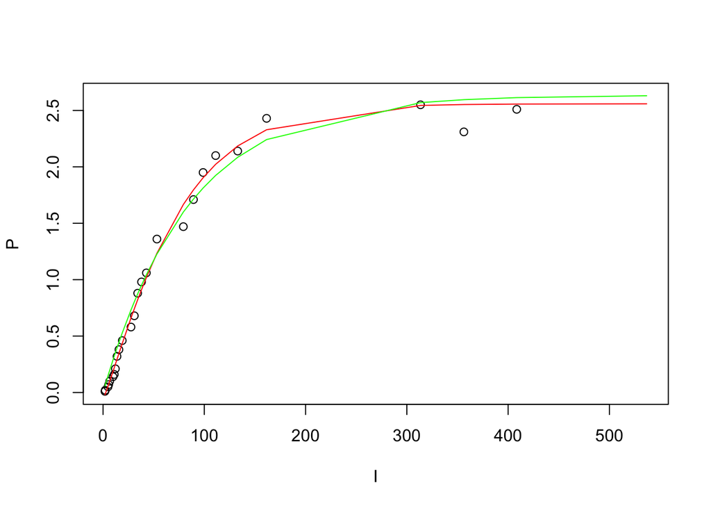

```r
c.weibull <- coef(weibull.nls)
c.weibull["alphaB"] <- exp(c.weibull["lrc"])*c.weibull["PsB"]
with(PI.df, {
               plot(I, P, ylim=c(0, PsB))
               lines(I, SSweibull(I, c.weibull["PsB"], c.weibull["Drop"],  c.weibull["lrc"],  c.weibull["pwr"]), col='red')
               lines(I, SSweibull(I, c.asymp["PsB"], c.asymp["PsB"],  c.asymp["lrc"], 1.0), col='green')
            })
```

```r
confint(weibull.nls)
```

```
##           2.5%     97.5%
## PsB   2.453213  2.671420
## Drop  2.449369  2.812646
## lrc  -5.790303 -4.172897
## pwr   0.968707  1.342265
```

Note that the estimated values for `Asym` and `Drop` are close, while the estimated value for `pwr` is close to unity. This indicates that the simpler `SSasympOrig` model (green line in the above plot) is preferable.

## Model with photoinhibition

Next we consider the model:

```
PB = PsB*(1 - exp(-alphaB*I/PsB))*exp(-betaB*I/PsB)
```

where `betaB` is allowed to vary. We will use log-transformed values, `lrca=log(alphaB/PsB)` and `lrcb=log(betaB/PsB)`.

We generate a test data set `PI2.df`:

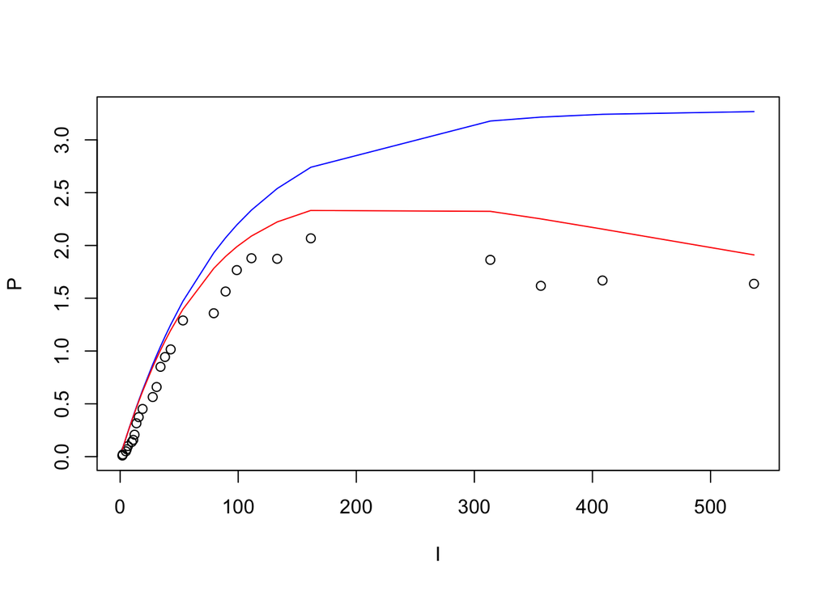

```r
PI2.df <- PI.df
PI2.df$P <- with(PI.df, P*exp(-0.001*I))
PIfun <- function(x, PsB, lrca, lrcb) {PsB*(1-exp(-exp(lrca)*x))*exp(-exp(lrcb)*x)}
PsB <- c.MM["PsB"]
alphaB <- c.MM["alphaB"]
lrca <- log(alphaB/PsB)
lrcb <-  log(0.001)
with(PI2.df, {
               plot(I, P, ylim=c(0, PsB))
               lines(I, SSProduction(I, alphaB, PsB), col='blue')
               lines(I, PIfun(I, PsB, lrca, lrcb), col='red')
            })
```

```r
PI2.nls <- nls(P ~ PsB*(1-exp(-exp(lrca)*I))*exp(-exp(lrcb)*I), data = PI2.df, start=list(PsB=PsB, lrca=lrca, lrcb=lrcb), trace=TRUE)
```

```
## 2.006938 :   3.275932 -4.490351 -6.907755
## 0.2870186 :   3.144255 -4.657191 -6.541415
## 0.2853131 :   3.205080 -4.690958 -6.531027
## 0.2852787 :   3.169982 -4.676636 -6.547692
## 0.2852754 :   3.179942 -4.680604 -6.543346
## 0.2852752 :   3.177200 -4.679477 -6.544629
## 0.2852751 :   3.177966 -4.679789 -6.544277
## 0.2852751 :   3.177753 -4.679702 -6.544376
## 0.2852751 :   3.177812 -4.679726 -6.544348
```

```r
PI2.nls
```

```
## Nonlinear regression model
##   model: P ~ PsB * (1 - exp(-exp(lrca) * I)) * exp(-exp(lrcb) * I)
##    data: PI2.df
##    PsB   lrca   lrcb
##  3.178 -4.680 -6.544
##  residual sum-of-squares: 0.2853
##
## Number of iterations to convergence: 8
## Achieved convergence tolerance: 6.058e-06
```

```r
summary(PI2.nls)
```

```
##
## Formula: P ~ PsB * (1 - exp(-exp(lrca) * I)) * exp(-exp(lrcb) * I)
##
## Parameters:
##      Estimate Std. Error t value Pr(>|t|)
## PsB    3.1778     0.6044   5.258 2.17e-05 ***
## lrca  -4.6797     0.2360 -19.833  < 2e-16 ***
## lrcb  -6.5443     0.2996 -21.841  < 2e-16 ***
## ---
## Signif. codes:  0 '***' 0.001 '**' 0.01 '*' 0.05 '.' 0.1 ' ' 1
##
## Residual standard error: 0.109 on 24 degrees of freedom
##
## Number of iterations to convergence: 8
## Achieved convergence tolerance: 6.058e-06
```

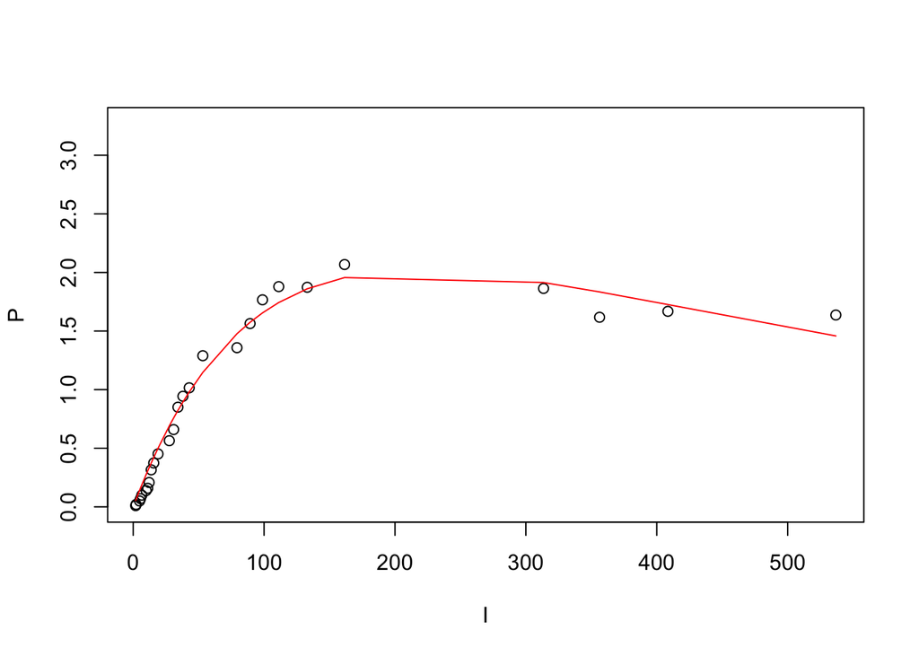

```r
c.PI2 <- coef(PI2.nls)
c.PI2["alphaB"] <- exp(c.PI2["lrc"])*c.PI2["PsB"]
with(PI2.df, {
               plot(I, P, ylim=c(0, PsB))
               lines(I, PIfun(I, c.PI2["PsB"], c.PI2["lrca"],  c.PI2["lrcb"]), col='red')
            })
```

```r
confint(PI2.nls)
```

[output not shown]

[output cut: 105 more lines]

[output not shown]

```
##           2.5%     97.5%
## PsB   2.421813  5.697075
## lrca -5.341779 -4.322514
## lrcb -7.183110 -5.958835
```

## Residuals

Both models appear, at first glance, to give reasonable fits to the data. It is, however, import to examine the fits carefully. The `nls` objects provide residuals:

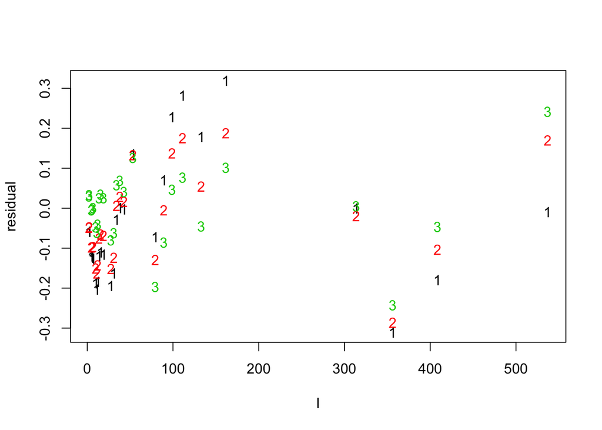

```r
with(PI.df, matplot(I, cbind(residuals(MM.nls), residuals(asymp.nls), residuals(weibull.nls)), ylab='residual'))
```

The largest residuals are all associated with the Michaelis-Menton model (1). Note that the residuals for this model are negative for small and large values of `I`. This suggests that the asymptotic model (2) is more appropriate for this data set. Residuals for 4-parameter Weibull (3) are similar to the aymptotic model (2), confirming that there is little benefit to the added complexity.

## Discussion

When there is no underlying justification for a particular model, it is useful to compare fits from several models. A model with additional parameters can be useful in confirming the results from a simpler model. For PI curves, the ultimate goal is to reduce a complicated data set to a consistent set of parameters to be used in numerical calculations.

It is also important to note that even in cases where the parameters have simple geometric interpretation (such as a slope at the origin or height of the asymptote) , estimated values for parameters should not be used with models other than the one used to generate the estimates.